# Problem Set 1

EJ Arce

1/23/2018

#### 1.1a

Population: high school students

Sample: 2000 high school students

Statistic: 47%

#### 1.1b

Population: US residents

Parameter: 13.9% of US residents are aged between 15 and 24 years

#### 1.1c

Population: NBA players

Parameter: average height (78.93 inches)

#### 1.1d

Population: US adults

Sample: A Gallop poll of 1,025 adults

Statistic: 47%

#### 1.3a

Experiment

#### 1.3b

Yes, because the study is an experiment

#### 1.3c

Yes, with a large sample, where volunteers were randomly assigned, the conclusions can be genaralized to the population of interest.

#### 1.5a

.00001

#### 1.5b

$$1- (1 - .00001)^{2000} = 1 - .9802 = .0198$$

#### 1.5c

$$.5 = 1 - (1 - .00001)^{x}$$

$$.5 = .99999^{x}$$

$$x = log_{.99999}(.5)$$

$$x = 69314.371482$$

For a probability of at least .5, 69315 samples must be collected.

#### 2.4a

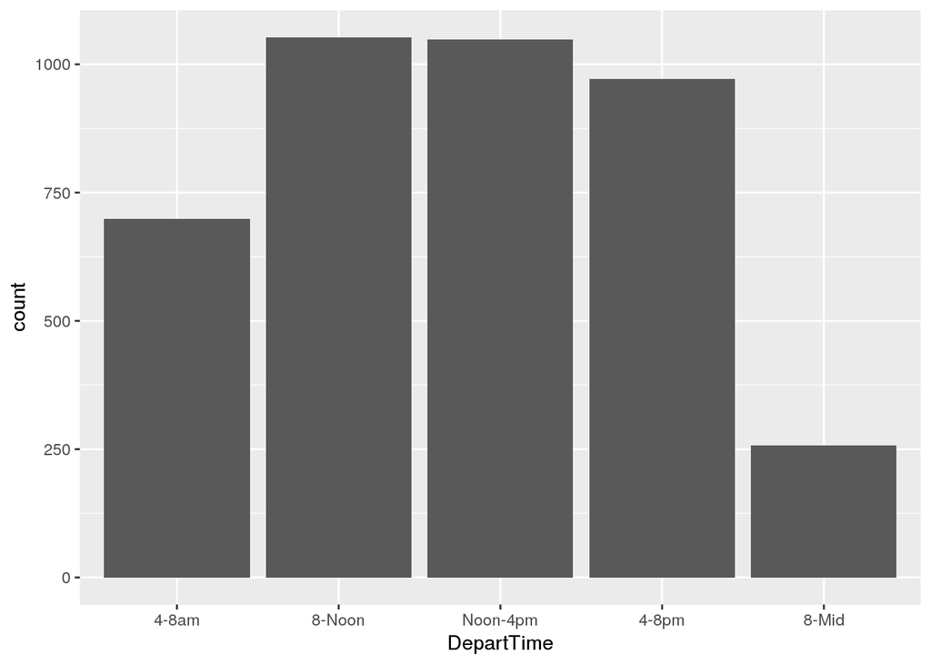

```r
bar <- ggplot(FlightDelays, aes(DepartTime)) + geom_bar()
bar
```

```r
table(FlightDelays$DepartTime)
```

```
##
##    4-8am   8-Noon Noon-4pm    4-8pm    8-Mid
##      699     1053     1048      972      257
```

#### 2.4b

```r
table(FlightDelays$Day,FlightDelays$Delayed30)
```

```
##
##        No Yes
##   Sun 507  44
##   Mon 569  61
##   Tue 535  93
##   Wed 488  76
##   Thu 434 132
##   Fri 493 144
##   Sat 406  47
```

Sunday: .0799

Monday: .0968

Tuesday: .1481

Wednesday: .1348

Thursday: .2332

Friday: .2261

Saturday: .1038

#### 2.8a

Solve for a:

##### First quartile

$$F(x) = \int_0^{a} \lambda e^{-\lambda x} ~dx = .25$$
$$-e^{-\lambda x} \rvert_{0}^{a} = .25$$
$$1 - e^{-\lambda a} = .25$$
$$e^{-\lambda a} = .75$$
$$-\lambda a = ln(.75)$$
$$a = \frac{ln(.75)}{\lambda}$$

##### Median

$$F(x) = \int_0^{a} \lambda e^{-\lambda x} ~dx = .5$$
$$-e^{-\lambda x} \rvert_{0}^{a} = .5$$
$$1 - e^{-\lambda a} = .5$$
$$e^{-\lambda a} = .5$$
$$-\lambda a = ln(.5)$$
$$a = \frac{ln(.5)}{\lambda}$$

##### Third quartile

$$F(x) = \int_0^{a} \lambda e^{-\lambda x} dx = .75$$
$$-e^{-\lambda x} \rvert_{0}^{a} = .75$$
$$1 - e^{-\lambda a} = .75$$
$$e^{-\lambda a} = .25$$
$$-\lambda a = ln(.25)$$
$$a = \frac{ln(.25)}{\lambda}$$

#### 2.8b

Solve for b:

##### First quartile

$$F(x) = \int_{1}^{b} \frac{\alpha}{x^{\alpha + 1}} dx = .25$$
$$\int_{1}^{b} x^{-\alpha - 1} dx = .25$$
$$x^{-\alpha}\rvert_{0}^{b} = .25$$
$$b^{\alpha} = .25$$
$$b = \sqrt[a]{.25}$$

##### Median

$$F(x) = \int_{1}^{b} \frac{\alpha}{x^{\alpha + 1}} dx = .5$$
$$\int_{1}^{b} x^{-\alpha - 1} dx = .5$$
$$x^{-\alpha}\rvert_{0}^{b} = .5$$
$$b^{\alpha} = .5$$
$$b = \sqrt[a]{.5}$$

##### Third quartile

$$F(x) = \int_{1}^{b} \frac{\alpha}{x^{\alpha + 1}} dx = .75$$
$$\int_{1}^{b} x^{-\alpha - 1} dx = .75$$
$$x^{-\alpha}\rvert_{0}^{b} = .75$$
$$b^{\alpha} = .75$$
$$b = \sqrt[a]{.75}$$

#### 2.9

Solve for x:

$$p = 1 − \frac{9}{x^2}$$
$$\frac{9}{x^2} = 1 - p$$
$$\frac{9}{1-p} = x^{2}$$
$$x = \sqrt{\frac{9}{1-p}}$$

#### 2.10

No, the binomial distribution is discrete (only supported on nonnegative integers), so there is no integer q such that F(q) = .05. When q = 2, F(q) = .0278, and when q = 3, F(q) = .0716.

#### 2.11

##### 1

The density plot of the simulated data is shown below, with red line indicating the theoretical density plot of the gamma distribution.

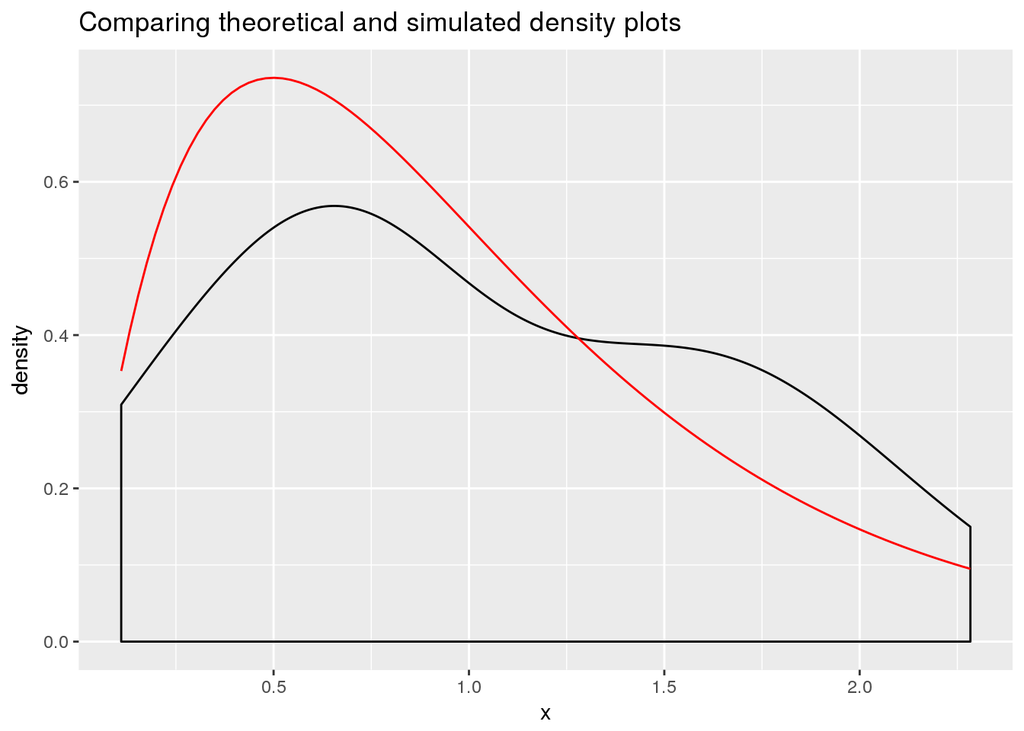

```r
set.seed(30)
d <- rgamma(20,2,2)
d <- data.frame(x=d)
ggplot(d, aes(x=x)) +
  geom_density() +
  stat_function(fun=dgamma,args=list(2,2), colour = "red") +
  ggtitle("Comparing theoretical and simulated density plots")
```

[figure not shown]

```r
set.seed(30)
ggplot() +
  geom_qq(aes(sample = rgamma(20,2,2))) +
  ggtitle("QQ plot of theoretical vs simulated data")
```

##### 2

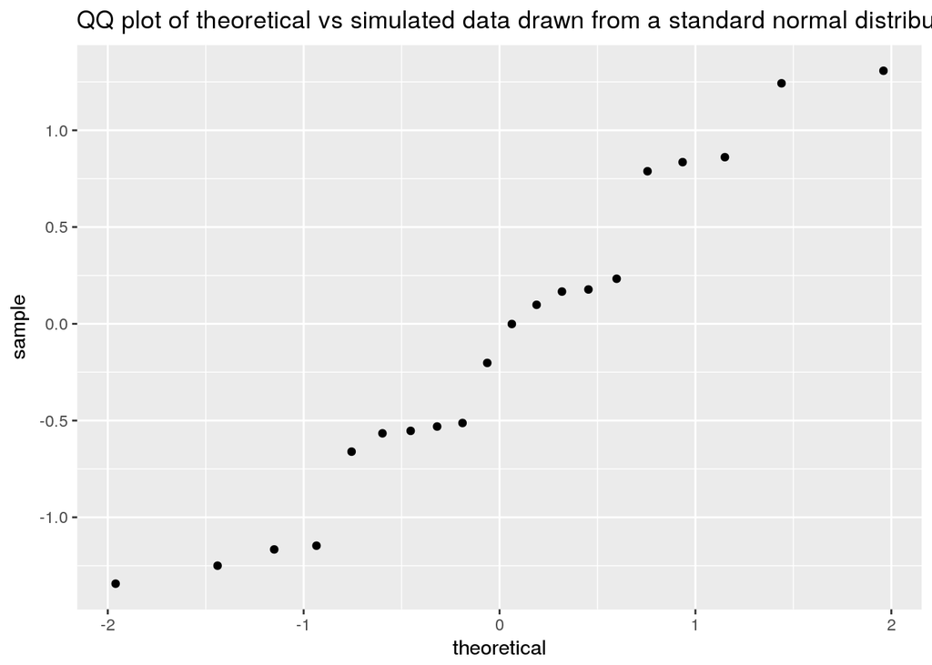

```r
set.seed(23)
ggplot() +
  geom_qq(aes(sample = rnorm(20,0,1))) +
  ggtitle("QQ plot of theoretical vs simulated data drawn from a standard normal distribution")
```

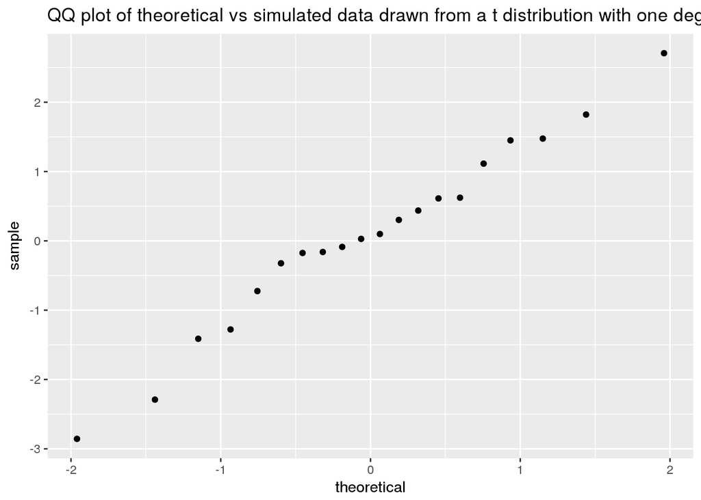

```r
ggplot() +
  geom_qq(aes(sample = rt(20,1))) +
  ggtitle("QQ plot of theoretical vs simulated data drawn from a t distribution with one degree of freedom")
```